# Rapport Rmarkdown des résultats et erreurs obtenues avec Panstripe & cafe5

ARQUE Maxime

2023-05-16

## — Partie Panstripe —

Utilisation des fichiers suivants :  
- ARBRE : concat-core-genes.phy_phyml_tree_GTR+I+G.txt  
- Matrice : matrice_binaire_equilibre.tab  
J’ai aussi créer une matrice “matrice_sans_COGs_non_binaires.tab” mais les problèmes rencontrés sont les mêmes avec les deux matrices.

~~~~ Chargement des librairies~~~~

```r
library(panstripe)
library(ape)
library(patchwork)
set.seed(1234)
```

~~~~ Chargement des fichiers nécéssaires pour l’utilisation des panstripe~~~~

```r
phylo.file.name="/home/maarque/Applications/Panstripe/Fichiers/concat-core-genes.phy_phyml_tree_GTR+I+G.txt"
rtab.file.name="/home/maarque/Applications/Panstripe/Fichiers/matrice_binaire_equilibre.tab"
tree <- read.tree(phylo.file.name)
pa <- read_rtab(rtab.file.name)
```

Le terminal annonce une (ou plusieurs erreurs), mais en utilisant problems(pa) rien ne s’affiche.

~~~~ Utilisation de panstripe pour générer le dataframe “fit”~~~~

```r
fit <- panstripe(pa, tree)

Error in value[[3L]](cond) :
  Panstripe model fit failed! This can sometime be caused by unusual branch lengths.
Setting fit_method='glmmTMB' or family='quasipoisson' or 'gaussian' often provides a more stable fit to difficult datasets

--> génère une erreur (qui semblerait être dûe à un problème de longueur de branches)
```

~~~~ Re-utilisation de panstripe, avec comme suggéré dans l’erreur, l’utilisation de d’autres settings ~~~~

–> Avec fit_method=“glmmTMB”, Rstudio se ferme donc impossible de l’utiliser

```r
fit <- panstripe(pa, tree, fit_method = "glmmTMB")
```

–> Avec family=“quasipoisson”

```r
fit <- panstripe(pa, tree, family = "quasipoisson")
fit$summary
```

| term | estimate | std.error | statistic | p.value | bootstrap CI 2.5% | bootstrap CI 97.5% |
| --- | --- | --- | --- | --- | --- | --- |
| istip | 1.501659 | 0.4990888 | 3.0088019 | 3.024208e-03 | 1.1696 | 2.0015 |
| core | 55.044195 | 39.2394820 | 1.4027758 | 1.625181e-01 | 31.3110 | 74.0250 |
| depth | 28.957140 | 2.7681787 | 10.4607190 | 4.620343e-20 | 26.1530 | 30.5590 |
| istip:core | -33.580036 | 45.3718732 | -0.7401069 | 4.602621e-01 | -56.4000 | 12.3320 |
| p | NA | NA | NA | NA | NA | NA |
| phi | NA | NA | NA | NA | NA | NA |

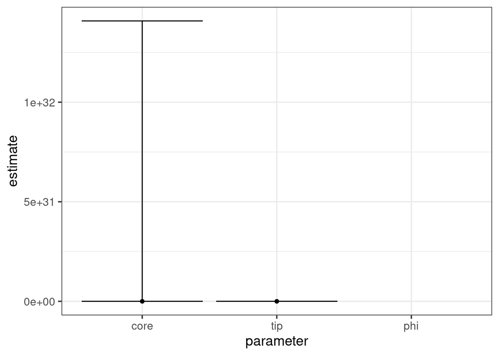

```r
plot_pangenome_params(fit)
```

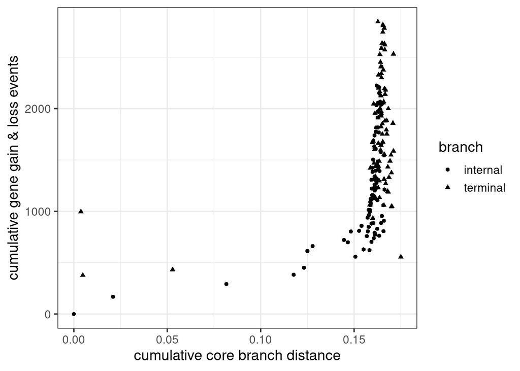

```r
plot_pangenome_cumulative(fit)
```

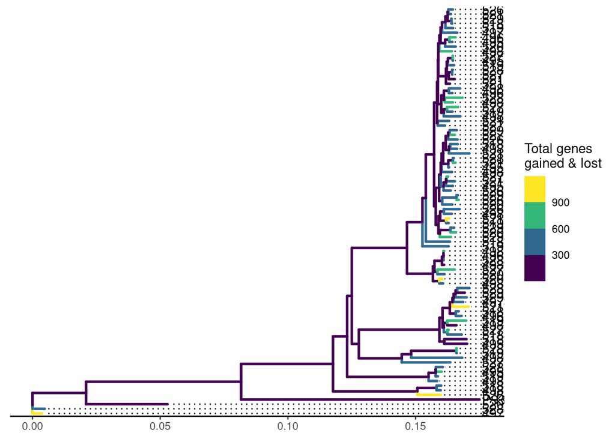

```r
plot_gain_loss(fit)
```

–> Avec family=“gaussian”

```r
fit <- panstripe(pa, tree, family = "gaussian")
fit$summary
```

| term | estimate | std.error | statistic | p.value | bootstrap CI 2.5% | bootstrap CI 97.5% |
| --- | --- | --- | --- | --- | --- | --- |
| istip | 389.0133 | 24.84088 | 15.6602058 | 9.951747e-35 | 333.57 | 441.23 |
| core | 1412.0487 | 1570.73602 | 0.8989726 | 3.699463e-01 | -694.05 | 2816.60 |
| depth | 773.2573 | 109.23238 | 7.0790118 | 3.711924e-11 | 614.65 | 898.76 |
| istip:core | -3309.7920 | 2214.39442 | -1.4946714 | 1.368651e-01 | -6632.80 | 6529.90 |
| p | NA | NA | NA | NA | NA | NA |
| phi | NA | NA | NA | NA | NA | NA |

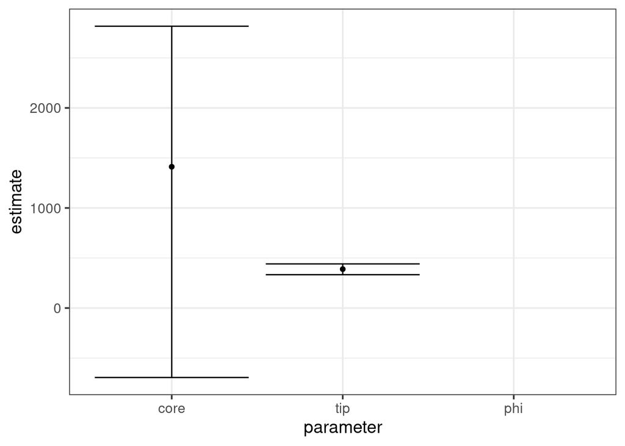

```r
plot_pangenome_params(fit)
```

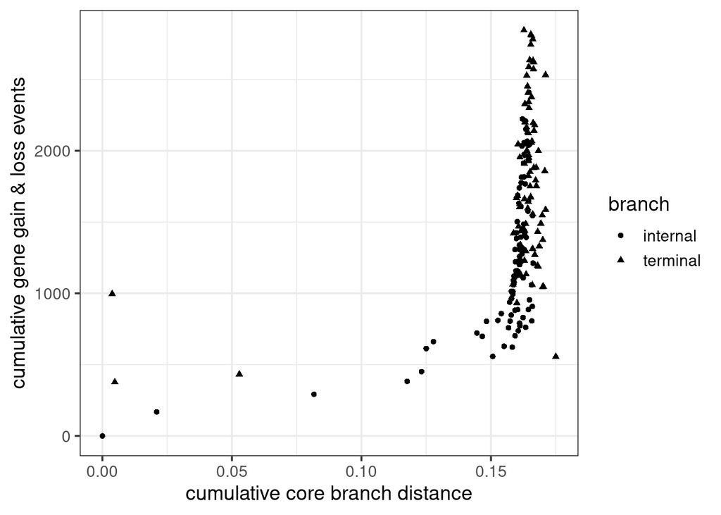

```r
plot_pangenome_cumulative(fit)
```

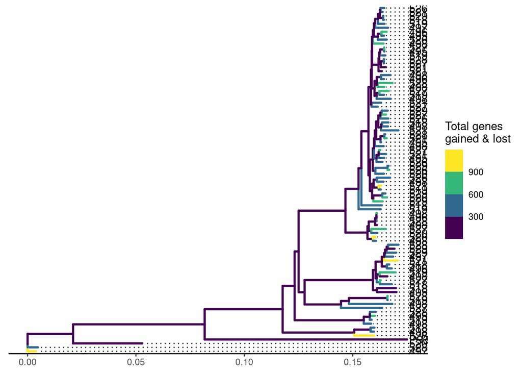

```r
plot_gain_loss(fit)
```

Globalement, en terme d’arbre, les deux paramètres semblent donner le même arbre (d’ailleurs, j’ai cherché comment modifier les labels sur l’arbre avec panstripe, mais pour le moment je n’ai pas trouvé). Cependant, pour les valeurs de core,phi, et tip les valeurs sont très différentes sachant que :  
- TIP : indique des associations avec des gènes observés sur les pointes de la phylogénie. Ceux-ci sont généralement entraînés par une combinaison d’erreurs d’annotation et en fonction de la densité d’échantillonnage temporelle également des éléments très mobiles qui ne sont pas observés dans plusieurs génomes.  
- CORE : indique si les longueurs de branche dans la phylogénie sont associées au gain et à la perte de gènes.  
- PHI : le paramètre d’indice inféré de la distribution Tweedie sous-jacente utilisée dans le GLM

## Panstripe + cafe5

Utilisation des fichiers suivants pour cafe5 :  
- ARBRE : concat-core-genes.phy_phyml_tree_GTR+I+G.txt  
- Matrice : cog_families.txt

Il semblait y’avoir un problème initialement avec la longueur des branches sur panstripe même avec l’utilisation de d’autres paramètres. En utilisant cafe5 j’ai eu un autre message d’erreur avec la commande suivante :

```r
cafe5 -i cog_families.txt -t ../concat-core-genes.phy_phyml_tree_GTR+I+G.txt -k 3

Erreur : Invalid branch length set for 496G15_C2 & 498N8_C2
```

J’ai donc utilisé R avec ape pour pouvoir chercher la longueur de ces branches et potentiellement identifier le problème.

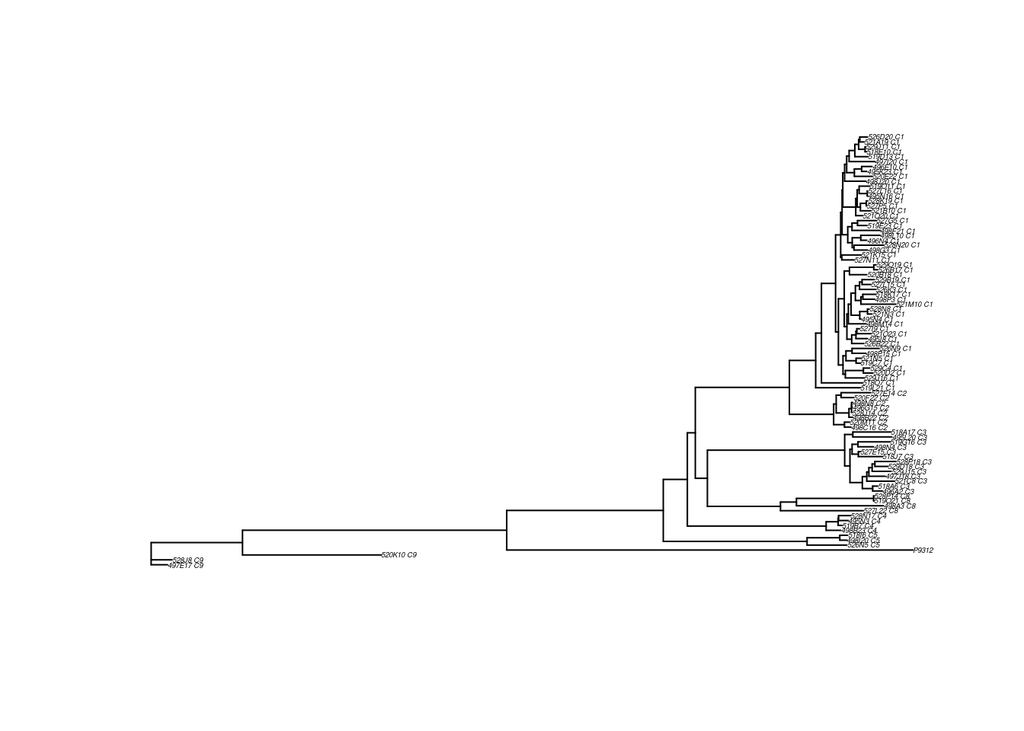

```r
library(ape)
tree=read.tree(file = "Fichiers/concat-core-genes.phy_phyml_tree_GTR+I+G.txt")
plot(tree, cex = 0.3)
```

Après ça j’ai cherché la longueur des branches en fonction de chaque SAGs :

```r
lengths=setNames(tree$edge.length[sapply(1:length(tree$tip.label),function(x,y) which (y==x),y=tree$edge[,2])],tree$tip.label)
print(lengths["496G15_C2"])
```

```
##  496G15_C2
## 0.00015106
```

```r
print(lengths["498N8_C2"])
```

```
##   498N8_C2
## 0.00025115
```

Ainsi 496G15_C2 = 0.00015106 et 498N8_C2 = 0.00025115. Les deux sont situées sur la même branche avec 528J14_C2

```r
print(lengths["528J14_C2"])
```

```
## 528J14_C2
## 7.628e-05
```

Et donc 528J14_C2 = 7.628e-05. Pour une vision plus globale de la longueur des branches :

```r
print(lengths)
```

```
##  497E17_C9   528J8_C9  520K10_C9      P9312   526N5_C5  498I20_C5   518I6_C5
## 0.00377523 0.00479156 0.03189634 0.09334875 0.00914513 0.00161217 0.00180654
##  498B23_C4   519B7_C4   495N3_C4  528N17_C4  527L22_C8   498A3_C8  519O21_C8
## 0.00337436 0.00089295 0.00224124 0.00273691 0.01900725 0.01998853 0.00010536
##  528P14_C8   496A2_C3   518A6_C3   521C8_C3  497J18_C3  529J15_C3  529D18_C3
## 0.00012581 0.00223872 0.00115288 0.00635987 0.00375947 0.00436058 0.00298856
##  528P18_C3   518J7_C3  527E15_C3   498N4_C3  519G16_C3  495L20_C3  518A17_C3
## 0.00482067 0.00556768 0.00047279 0.00360283 0.00740752 0.00897107 0.00874491
##  498C16_C2  520M11_C2  498B22_C2  528J14_C2  496G15_C2   498N8_C2  520F22_C2
## 0.00149447 0.00119457 0.00084056 0.00007628 0.00015106 0.00025115 0.00283260
##  527E14_C2  519L21_C1   518O7_C1  529J16_C1   520D2_C1   529C4_C1   519C7_C1
## 0.00679612 0.01026951 0.00946008 0.00436437 0.00219450 0.00147283 0.00100172
##   521N5_C1  498P15_C1   526N9_C1  526B22_C1   495I8_C1  521O23_C1   527I9_C1
## 0.00118767 0.00315862 0.00622393 0.00278293 0.00267550 0.00325428 0.00060302
##  498M14_C1   495N4_C1   521N3_C1   528N8_C1  521M10_C1   498P3_C1  518K17_C1
## 0.00408711 0.00029973 0.00103885 0.00038272 0.00801075 0.00272741 0.00295945
##   526K3_C1  527L15_C1  529B19_C1  520B18_C1  526B17_C1  529O19_C1  527N11_C1
## 0.00366719 0.00204053 0.00281201 0.00396650 0.00088416 0.00052470 0.00284158
##  521K15_C1   498G3_C1  528N20_C1   496N4_C1  498L10_C1  498F21_C1  519E23_C1
## 0.00443898 0.00312063 0.00684880 0.00137968 0.00443471 0.00650919 0.00217749
##   527G5_C1  521O20_C1  521B10_C1   527P5_C1  528K19_C1  495N16_C1  527L16_C1
## 0.00433876 0.00156711 0.00239358 0.00008811 0.00028451 0.00008883 0.00006230
##  519O11_C1  498J20_C1  520E22_C1  495K23_C1  496E10_C1  497I20_C1  519D13_C1
## 0.00242293 0.00488070 0.00413762 0.00118990 0.00240061 0.00594224 0.00301181
##  518E10_C1  529J11_C1  521A19_C1  526D20_C1
## 0.00030508 0.00009532 0.00099277 0.00177174
```

Cependant je n’ai pas réussi à comprendre pourquoi les deux longueurs de branches de 496G15_C2 et 498N8_C2 posent problème, et surtout s’il y’en a d’autres en dehors de ces deux là avec lesquelles il y’a un problème (je pense que s’il y’avait d’autres branches problématiques dans le message d’erreur, les autres auraient été signalées aussi mais on sait jamais)  
Pour count, tout semble marcher correctement (pas de messages d’erreurs) et fonctionne avec les 3 matrices : la matrice initiale d’Hélène GARDON (ALL.cogs2.matrix) que j’ai modifié pour que le format corresponde, la matrice “matrice_binaire_equilibre_count.tab” avec tous les notations au dessus de 1 ramenées à 1 et la matrice “matrice_sans_COGs_non_binaires_count.tab” ou j’ai supprimé toutes les lignes avec des valeurs au dessus de 1 (au final on passe de 7825 lignes à 7644 soit seulement 181 COGs en moins, c’est qui est pas si grand que ça)